# Practical Machine Learning: Prediction Assignment

Harrison Lin

February 7, 2016

## Preprocessing:

```r
  library(forecast)
  library(caret)
```

```r
  library(ggplot2)

  data.Path <- "D:/Cloud/Google Drive/Coursera/Practical Machine Learning/Project/"

  data.file.training <- paste(data.Path, "pml-training.csv", sep='')
  data.file.testing <- paste(data.Path, "pml-testing.csv", sep='')

    # training data
  data.training = read.csv(data.file.training)

  # testing data
  data.testing = read.csv(data.file.testing)
```

### Belt Variables

Here we build a feature plot between the dependent variable, classe against the variables, roll_belt, pitch_belt, and yaw_belt

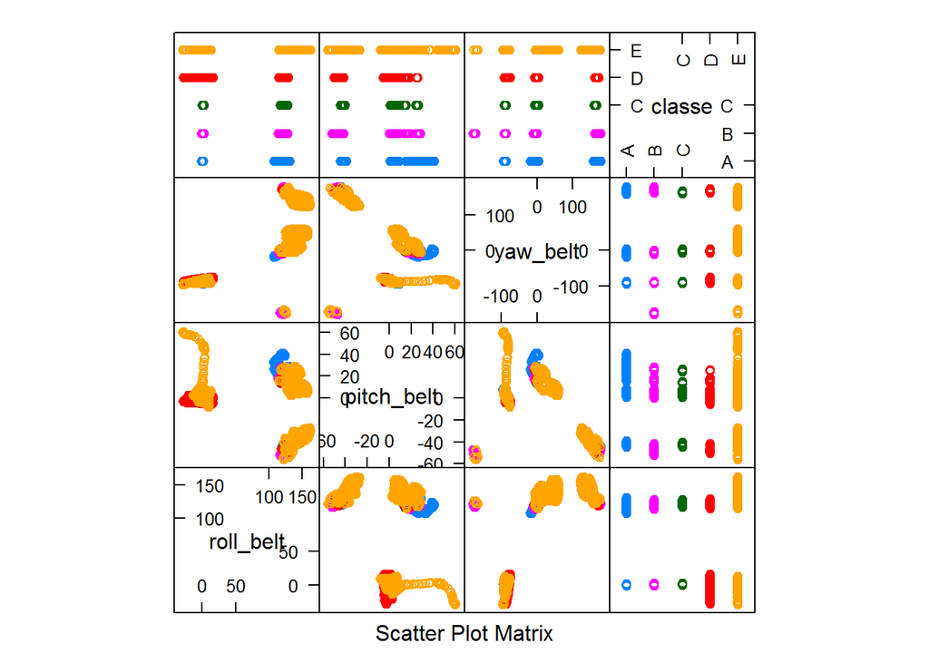

```r
  featurePlot(x=data.training[, c("roll_belt", "pitch_belt", "yaw_belt", "classe")],
              y=data.training[,c("classe")], plot="pairs")
```

#### Result:

The dependent variable, classe, on the belt variables, Roll_belt, Pitch_belt, Yaw_belt are correlated.

### Arm Variables

Here we build a feature plot between the dependent variable, classe against the variables, roll_arm, pitch_arm, and yaw_arm

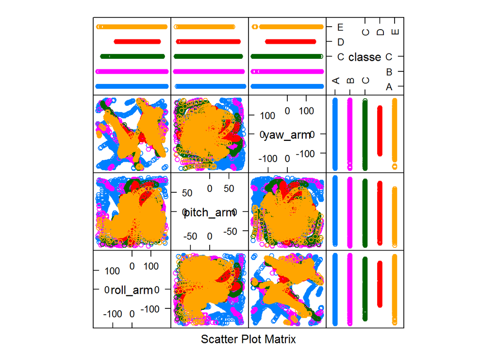

```r
  featurePlot(x=data.training[, c("roll_arm", "pitch_arm", "yaw_arm", "classe")],
              y=data.training$classe, plot="pairs")
```

#### Result:

This shows the various Arm variables, roll_arm, pitch_arm and yaw_arm variables are not correlated with our dependent variables in classe.

### Dumbbell Variables:

There are four sets of variables, on the third set of variables, we build a feature plot between the dependent variable, classe against the variables, roll_dumbbell, pitch_dumbbell, and yaw_dumbbell.

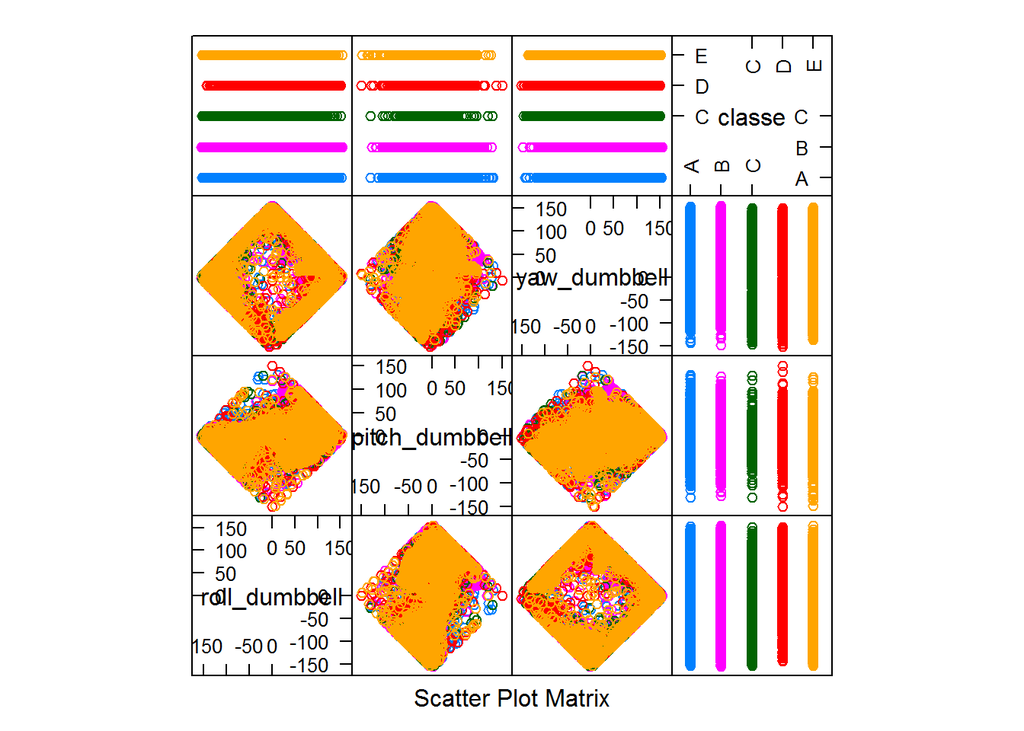

```r
  featurePlot(x=data.training[, c("roll_dumbbell", "pitch_dumbbell", "yaw_dumbbell", "classe")],
              y=data.training$classe, plot="pairs")
```

#### Result:

Dumbbell variables, roll_dumbbell, pitch_dumbbell and yaw_dumbbell have no significant correlation to our dependent variables in classe.

### Forearm Variables

Finally, on the last set of variables, we build a feature plot between the dependent variable, classe against the variables, roll_forearm, pitch_forearm, and yaw_forearm.

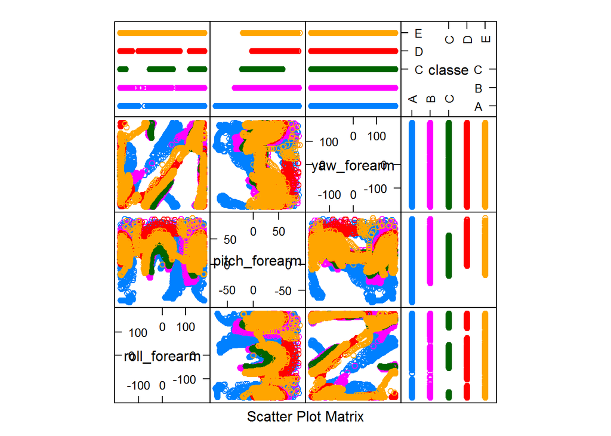

```r
  featurePlot(x=data.training[, c("roll_forearm", "pitch_forearm", "yaw_forearm", "classe")], y=data.training$classe, plot="pairs")
```

#### Result:

Hence forearm variables, roll_forearm, pitch_forearm, and yaw_forearm has no significant correlation to classe variable. Some exceptions are observed, such as Roll_forearm variable shows some clustering effects and pitch_forearm shows no data in lower end spectrum.

## Prediction Models

We first set the seed:

```r
  set.seed(1234)
```

### Classification Trees:

We first explore the possibility to train a classification tree for the three variables we found correlated with the dependent variable, classe. The three variables belongs to the belt exercises, they are roll_belt, pitch_belt and yaw_belt.

```r
  model.tree.fit <- train(classe ~ roll_belt + pitch_belt + yaw_belt, data=data.training, method="rpart")
  print(model.tree.fit$finalModel)
```

```
## n= 19622
##
## node), split, n, loss, yval, (yprob)
##       * denotes terminal node
##
## 1) root 19622 14042 A (0.28 0.19 0.17 0.16 0.18)
##   2) roll_belt< 130.5 17977 12411 A (0.31 0.21 0.19 0.18 0.11)
##     4) roll_belt>=-0.615 17108 11560 A (0.32 0.22 0.2 0.17 0.085) *
##     5) roll_belt< -0.615 869   348 E (0.021 0.01 0 0.37 0.6) *
##   3) roll_belt>=130.5 1645    14 E (0.0085 0 0 0 0.99) *
```

```r
  model.tree.fit$results
```

```
##           cp  Accuracy      Kappa AccuracySD    KappaSD
## 1 0.02378579 0.4455838 0.25230264 0.06916309 0.11272778
## 2 0.03582111 0.3804089 0.14690039 0.01462941 0.02136575
## 3 0.11515454 0.3234963 0.05935945 0.04095376 0.06310961
```

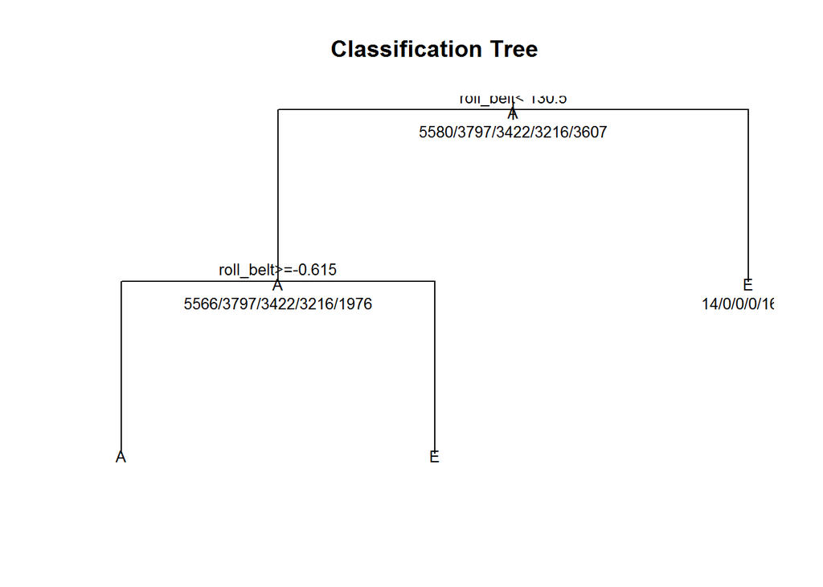

```r
  plot(model.tree.fit$finalModel, uniform=TRUE, main="Classification Tree")
  text(model.tree.fit$finalModel, use.n=TRUE, all=TRUE, cex=0.8)
```

```r
  predict(model.tree.fit, newdata=data.testing)
```

```
##  [1] A A A A A E A A A A A A A A A A A A A A
## Levels: A B C D E
```

#### Results:

The classification tree produced accuracy less than 0.47.

### Random Forest:

We then train a Random Forest model for the three variables we found correlated with the dependent variable, classe. The three variables belongs to the belt exercises, they are roll_belt, pitch_belt and yaw_belt. We find other set of variables, including arm, forearm and dumbbell insignificantly correlated with our dependent variable, classe, and not included in our analysis for keeping the model arsimonious.

```r
# model.randomForest.fit <- train(classe ~ roll_belt + pitch_belt + yaw_belt, data=data.training, method="rf")

# print(model.randomForest.fit)


# model.randomForest.predict <- predict(model.randomForest.fit, data.testing)
# print(model.randomForest.predict)
```

### Boosting:

Finally, We train a stochastic Boosting model for the three variables we found correlated with the dependent variable, classe. The three variables belongs to the belt exercises, they are roll_belt, pitch_belt and yaw_belt.

These models are trained with identical set of covariates, enabling us to figure out the best performing models among the three choices in classification trees, random forest and boosting. We find other set of variables, including arm, forearm and dumbbell insignificantly correlated with our dependent variable, classe, and not included in our models.

```r
#model.boosting.fit <- train(classe ~ roll_belt + pitch_belt + yaw_belt, data=data.training, method="gbm", verbose=FALSE)
#print(model.boosting.fit)
#print(model.boosting.fit$results)
```

```r
#  model.boosting.predict <- predict(model.boosting.fit, data.testing)
#  print(model.boosting.predict)
```